# Data Scientist Exercise: Working with a beer review dataset using R

Jin-Long Lyu

March 17, 2019

## Introduction

1. Which brewery produces the strongest beers by ABV%?
2. If I had to pick 3 beers to recommend using only this data, which would I pick?
3. Which of the factors (aroma, taste, appearance, palette) are most important in determining the overall quality of a beer?
4. Lastly, if I typically enjoy a beer due to its aroma and appearance, which beer style should I try?

## Beer Reviews Dataset

This tabular data consists of approximately 1.5 million beer reviews from Beer Advocate, and reviewers evaluated beers in term of aroma, appearance, palate and taste in a scale of 0 - 5 points (decimal accepted).

## Data at a glance

Showing the firtst 5 rows of data

```r
kable(head(data,5)) %>%
   kable_styling(bootstrap_options = c("striped", "hover","bordered"), position = "center" ) %>% row_spec(0,background= "#F6D08A",color='#DF6002')
```

| brewery_id | brewery_name | review_time | review_overall | review_aroma | review_appearance | review_profilename | beer_style | review_palate | review_taste | beer_name | beer_abv | beer_beerid |
| --- | --- | --- | --- | --- | --- | --- | --- | --- | --- | --- | --- | --- |
| 10325 | Vecchio Birraio | 1234817823 | 1.5 | 2.0 | 2.5 | stcules | Hefeweizen | 1.5 | 1.5 | Sausa Weizen | 5.0 | 47986 |
| 10325 | Vecchio Birraio | 1235915097 | 3.0 | 2.5 | 3.0 | stcules | English Strong Ale | 3.0 | 3.0 | Red Moon | 6.2 | 48213 |
| 10325 | Vecchio Birraio | 1235916604 | 3.0 | 2.5 | 3.0 | stcules | Foreign / Export Stout | 3.0 | 3.0 | Black Horse Black Beer | 6.5 | 48215 |
| 10325 | Vecchio Birraio | 1234725145 | 3.0 | 3.0 | 3.5 | stcules | German Pilsener | 2.5 | 3.0 | Sausa Pils | 5.0 | 47969 |
| 1075 | Caldera Brewing Company | 1293735206 | 4.0 | 4.5 | 4.0 | johnmichaelsen | American Double / Imperial IPA | 4.0 | 4.5 | Cauldron DIPA | 7.7 | 64883 |

```r
dtypes<- data.frame(sapply(data, class))
dtypes <- cbind(newColName = rownames(dtypes), dtypes)
rownames(dtypes) <- 1:nrow(dtypes)
colnames(dtypes)<-c('Column Name','Data Type')
kable(dtypes) %>%
   kable_styling(bootstrap_options = c("striped", "hover","bordered"), position = "center" ) %>% row_spec(0,background= "#F6D08A",color='#DF6002')
```

| Column Name | Data Type |
| --- | --- |
| brewery_id | character |
| brewery_name | character |
| review_time | integer |
| review_overall | numeric |
| review_aroma | numeric |
| review_appearance | numeric |
| review_profilename | character |
| beer_style | character |
| review_palate | numeric |
| review_taste | numeric |
| beer_name | character |
| beer_abv | numeric |
| beer_beerid | character |

## 1. Which brewery produces the strongest beers by ABV%?

The brewery that produces the strongest beers is Schorschbrau.

1. Schorschbrau
2. BrewDog
3. De Struise Brouwers
4. Hair of the Dog Brewing Company / Brewery and Tasting Room
5. Boston Beer Company (Samuel Adams)

```r
data1.1 <- data.frame(data %>% group_by(brewery_name) %>% summarise(beer_abv = max(beer_abv)))
data1.1 <- data1.1[order(data1.1[,'beer_abv'],decreasing = TRUE),][1:10,]
kable(data1.1) %>%
   kable_styling(bootstrap_options = c("striped", "hover","bordered"), position = "center")%>% row_spec(0,background= "#F6D08A",color='#DF6002')%>% row_spec(1,background= "yellow")
```

|  | brewery_name | beer_abv |
| --- | --- | --- |
| 4222 | Schorschbräu | 57.70 |
| 1104 | BrewDog | 41.00 |
| 1740 | De Struise Brouwers | 39.00 |
| 2323 | Hair of the Dog Brewing Company / Brewery and Tasting Room | 29.00 |
| 646 | Boston Beer Company (Samuel Adams) | 27.00 |
| 2901 | LagerHaus Grill & Brewery | 22.00 |
| 1836 | DuClaw Brewing Company | 21.92 |
| 2224 | Grand Lake Brewing Company | 20.00 |
| 4279 | Short’s Brewing Company | 20.00 |
| 412 | BFM Brasserie Des Franches-Montagnes | 19.50 |

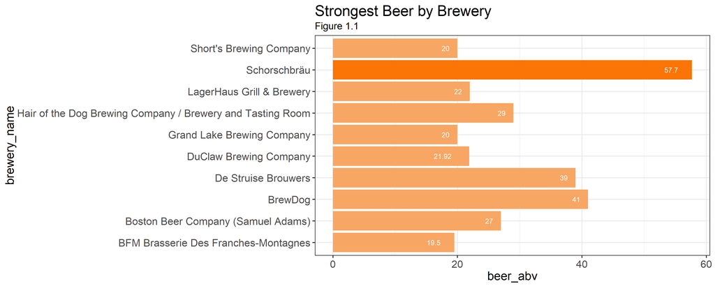

```r
fig1.1
```

## 2. Best Beers: Personally Recommended

For me to define the perfect beer that I enjoy drinking the most, I really prefer the one that is not so strong; ideally, 5% to 10% of ABV% is the best. On top of that, the best beer is dominant in terms of overall review score and the popularity (number of reviews), and last but not least, the beer is from the most reputational brewery.

My condictions of best beers are shown as the following:

1. Beers ABV% is between 5% to 10% (Fig. 2.1)
2. Popular beers whose number of reviews is 90th percentile and review overall score is 70th percentile (Fig. 2.2)
3. Most reputational brewery whose review overall score is 90th percentile and number of reviews is above average (Fig. 2.3)

```r
# get a list of beers whose ABV% is between 5% to 10%
lower_abv <- 5
higher_abv <- 10
cond1_beers <- data[ which(data$beer_abv>=lower_abv&data$beer_abv<=higher_abv),]

# get a list of beers whose review count is higher than the data population average
p2_c <- 0.9
p2_m <- 0.7
agg2 <- data.frame(data %>% group_by(brewery_name,beer_name,beer_abv) %>% summarize(count=n(),mean=mean(review_overall)))
thresh2_c <- quantile(agg2$count,p2_c)
thresh2_m <- quantile(agg2$mean,p2_m)
cond2_beer <- agg2[which(agg2$count>thresh2_c & agg2$mean>thresh2_m),]

# get a list of reputational brewery that have above-average review counts (popularity) and its average review scores is among the top 10% in the population
p3 <- 0.9
agg3 <- data.frame(data %>% group_by(brewery_name) %>% summarize(count=n(),mean=mean(review_overall)))
thresh3_c <- mean(agg3$count)
thresh3_m <- quantile(agg3$mean,p3)
reputational_brewery <- agg3[which(agg3$count>thresh3_c & agg3$mean>thresh3_m),'brewery_name']

fig2.1_df <- data.frame(group=c('Below 5%', '5% - 10%', 'Above 10%'),value=c(dim(data[which(data$beer_abv<lower_abv),])[1]/dim(data)[1],dim(cond1_beers)[1]/dim(data)[1],dim(data[which(data$beer_abv>higher_abv),])[1]/dim(data)[1]))

fig2.1 <- ggplot(fig2.1_df, aes(x="", y=value, fill=group))+
geom_bar(width = 1, stat = "identity") + geom_col() + geom_text(aes(label = scales::percent(round(value,3))), position = position_stack(vjust = 0.5))+
   coord_polar(theta = "y") +
   theme_void() + ggtitle('How ABV% is distributed in data?',subtitle = 'Figure 2.1')

fig2.2 <- ggplot(agg2,aes(y=mean,x=count)) + geom_point(color="red") +  ggtitle('Number of Reviews v.s. Review Scores (Per Beer)',subtitle = 'Figure 2.2') + theme_minimal() +
  xlab("Number of Review") + ylab('Review Score') + geom_hline(yintercept=thresh2_m)+ geom_vline(xintercept=thresh2_c) +
     annotate("rect", xmin = thresh2_c, xmax = 3500, ymin = thresh2_m, ymax = 5,alpha = .3,color='blue')

fig2.3 <- ggplot(agg3,aes(y=mean,x=count)) + geom_point(color="blue") +  ggtitle('Which brewery is most reputational?',subtitle = 'Figure 2.3') + theme_minimal() +
  xlab("Number of Review") + ylab('Review Score') + geom_hline(yintercept=thresh3_m)+ geom_vline(xintercept=thresh3_c) +
     annotate("rect", xmin = thresh3_c, xmax = 40000, ymin = thresh3_m, ymax = 5,alpha = .3,color='blue')
```

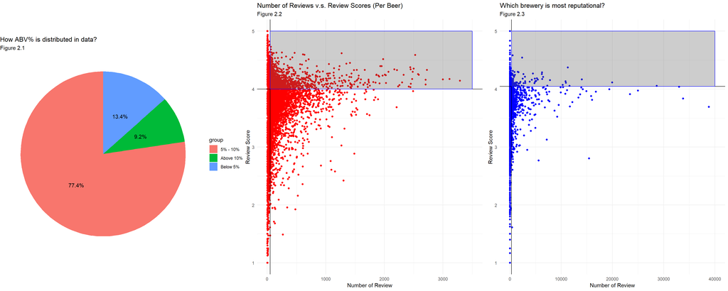

```r
grid.arrange(fig2.1, fig2.2,fig2.3, nrow = 1)
```

Generating the list of best beers and selecting top 3 beers (based on review score):

Best Beer No.1 : Armand’4 Oude Geuze Lente (Spring) (Brouwerij Drie Fonteinen)

Best Beer No.2 : Hoppy Birthday (Alpine Beer Company)

```r
cond2_beer <- cond2_beer %>% mutate_at(vars(starts_with("mean")), funs(round(., 2)))
beers <- cond2_beer[order(cond2_beer$mean,cond2_beer$count,decreasing = TRUE),]

recommenedBeers <- list()
recommenedBeersDF <- data.frame(matrix(ncol = 4, nrow = 0))
colnames(recommenedBeersDF) <- c('Beer','Brewery','Review Score (Overall)','Beer ABV%')
l <- 0
idx <- 1
while (l != 3 & idx <= dim(beers)[1]){
  beer = beers[idx,'beer_name']
  brewery = beers[idx,'brewery_name']
  RS <- beers[idx,'mean']
  beer_abv <- beers[idx,'beer_abv']
  if(brewery %in% reputational_brewery & beer %in% unique(cond1_beers[,'beer_name'])){
    s <- sprintf('Best Beer No.%s :%s (%s)',l+1,beer,brewery)
    print(s)
    recommenedBeers[l+1] = s
    recommenedBeersDF[l+1,]=c(beer,brewery,RS,beer_abv)
    l<- length(recommenedBeers)
  }
  idx <- idx+1
}
```

```
## [1] "Best Beer No.1 :Armand'4 Oude Geuze Lente (Spring) (Brouwerij Drie Fonteinen)"
## [1] "Best Beer No.2 :Hoppy Birthday (Alpine Beer Company)"
## [1] "Best Beer No.3 :Heady Topper (The Alchemist)"
```

```r
kable(recommenedBeersDF) %>%
   kable_styling(bootstrap_options = c("striped", "hover","bordered"), position = "center")%>% row_spec(0,background= "#F6D08A",color='#DF6002')%>% row_spec(1,background= "yellow")
```

| Beer | Brewery | Review Score (Overall) | Beer ABV% |
| --- | --- | --- | --- |
| Armand’4 Oude Geuze Lente (Spring) | Brouwerij Drie Fonteinen | 4.73 | 6 |
| Hoppy Birthday | Alpine Beer Company | 4.68 | 5.25 |
| Heady Topper | The Alchemist | 4.63 | 8 |

## 3. Which of the factors (aroma, taste, appearance, palette) are most important in determining the overall quality of a beer?

In terms of a good quality of a beer, let’s assume the review overall score in data represents the overall quality of beers. Now that we already have data representing the overall quality of beers, the next thing that we are wondering now is that which one of these factors(aroma, taste, appearance & palette) is most important in affecting the scoring of the review overall variable (dependent variable).

One way to figure out the relationships between each of thsee variables and its dependent variable, we can fit a linear regression model and compare some of the crucial statistics, such as R-squared and regression coefficients, to find out the answer for us.

# Method 1: Comparing the coefficients

After fitting a linear regression model, we can observe that review_taste has the highest values of coefficient among all variables, which implies that review_taste is the most important variable in determining the values of the review overall score; in other words, it is the most important factor in determining a good quality of a beer.

```r
lm1 <- lm(review_overall~review_aroma+review_appearance+review_palate+review_taste,data = data)
lm1.summary <- summary(lm1)
lm1.summary
```

```
##
## Call:
## lm(formula = review_overall ~ review_aroma + review_appearance +
##     review_palate + review_taste, data = data)
##
## Residuals:
##     Min      1Q  Median      3Q     Max
## -3.8681 -0.2570 -0.0067  0.2453  3.6610
##
## Coefficients:
##                    Estimate Std. Error t value Pr(>|t|)
## (Intercept)       0.4477379  0.0023713  188.82   <2e-16 ***
## review_aroma      0.0476247  0.0007406   64.31   <2e-16 ***
## review_appearance 0.0357281  0.0007168   49.84   <2e-16 ***
## review_palate     0.2579818  0.0007785  331.37   <2e-16 ***
## review_taste      0.5498900  0.0007957  691.08   <2e-16 ***
## ---
## Signif. codes:  0 '***' 0.001 '**' 0.01 '*' 0.05 '.' 0.1 ' ' 1
##
## Residual standard error: 0.4219 on 1518824 degrees of freedom
## Multiple R-squared:  0.6541, Adjusted R-squared:  0.6541
## F-statistic: 7.18e+05 on 4 and 1518824 DF,  p-value: < 2.2e-16
```

note: in order to ensure we can compare the coefficients without problem, we need to know that aroma, taste, appearance, palette and overall score use the same scale (0 to 5).

# Method 2: Comparing the Values of R-Squared

We can also identify the most important feature by looking at the increase in R-squared when each variable is added to a model that already contains all of the other variables. It is obvious that review_taste has the highest increase in R-squared, which can be interpreted that it is the most important variable in determining good qaulity of beers just like method 1.

```r
r2_df <- data.frame(matrix(ncol = 3, nrow = 0))
colnames(r2_df) <- c('Variable','R-Squared With All Other Variables','R-Squared Incresae')
r2 <- lm1.summary$r.squared
data.3 <- data[,c('review_aroma', 'review_appearance','review_palate', 'review_taste','review_overall')]
idx<-1
for (drop in c('review_aroma', 'review_appearance','review_palate', 'review_taste')){
  data.loop<-data.3[,!(names(data.3)%in%drop)]
  lm.loop<-lm(review_overall~.,data = data.loop)
  lm.loop.summary <- summary(lm.loop)
  r2_df[idx,]=c(drop,round(lm.loop.summary$r.squared,4),round((r2-lm.loop.summary$r.squared),4))
  idx <- idx+1
}
kable(r2_df[order(r2_df$`R-Squared With All Other Variables`,decreasing = FALSE),]) %>%
   kable_styling(bootstrap_options = c("striped", "hover","bordered"), position = "center")%>% row_spec(0,background= "#F6D08A",color='#DF6002')%>% row_spec(1,background= "yellow")
```

|  | Variable | R-Squared With All Other Variables | R-Squared Incresae |
| --- | --- | --- | --- |
| 4 | review_taste | 0.5453 | 0.1088 |
| 3 | review_palate | 0.6291 | 0.025 |
| 1 | review_aroma | 0.6532 | 9e-04 |
| 2 | review_appearance | 0.6535 | 6e-04 |

## 4. Lastly, if I typically enjoy a beer due to its aroma and appearance, which beer style should I try?

Let’s assume if a beer has the best aroma and appearance scores, then it’d score high in the review data (specifically review_aroma and review_appearance), and we can then compute the combined score of aroma and appearance by taking their mean. After sorting the result, it is observed that American Double / Imperial Stout is the most ideal beer style to try for it has the highest combined score of aroma and appearance.

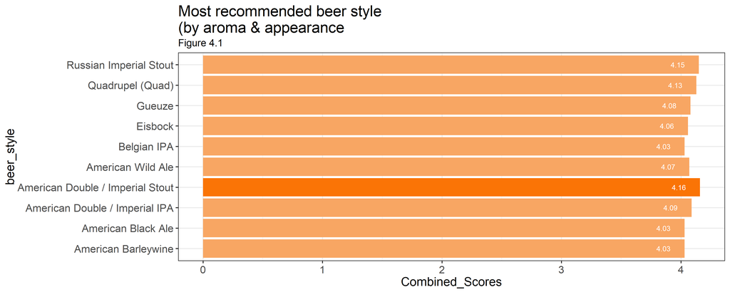

```r
fig4.1
```